# Hidden Markov Models: Basics for animal movement data

## 6.4 Effects of interpolation

The seal data we are using is not regular, by which I mean that the locations are not taken at regular time intervals. As a quick trick we regularised the data to 2 hours intervals using linear interpolation, but this is likely to affect the analysis. Here, explore the effects of using different time intervals. For example, look at the results when using 1, 4, 8 hours intervals. Look at both the fit of the model and the pseudo residuals. We commented out the plots for space, but do run them to visualise the effect of resolution on the data and results.

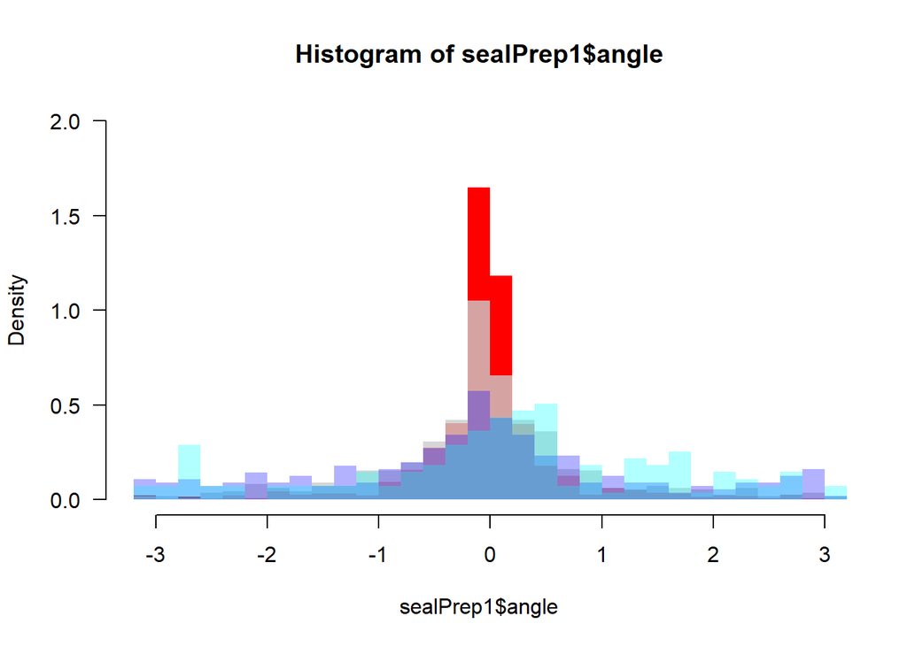

```r
# Let's try different time intervals
# 1 hr
ti1 <- seq(seal$date[1], seal$date[length(seal$date)], by=60*60)
# 4 hr
ti4 <- seq(seal$date[1], seal$date[length(seal$date)], by=4*60*60)
ti8 <- seq(seal$date[1], seal$date[length(seal$date)], by=8*60*60)

# Interpolate the location at the times from the sequence
iLoc1 <- as.data.frame(cbind(lon=approx(seal$date, seal$lon,
                                        xout = ti1)$y,
                             lat=approx(seal$date, seal$lat,
                                        xout = ti1)$y))
iLoc4 <- as.data.frame(cbind(lon=approx(seal$date, seal$lon,
                                        xout = ti4)$y,
                             lat=approx(seal$date, seal$lat,
                                        xout = ti4)$y))
iLoc8 <- as.data.frame(cbind(lon=approx(seal$date, seal$lon,
                                        xout = ti8)$y,
                             lat=approx(seal$date, seal$lat,
                                        xout = ti8)$y))

# Create a new object that has the regular time and interpolated locations
sealreg1 <- cbind(date=ti1, iLoc1)
sealreg4 <- cbind(date=ti4, iLoc4)
sealreg8 <- cbind(date=ti8, iLoc8)

# # Quickly plot the regularized locations
# plot(seal$lon, seal$lat,
#      pch=19, cex=0.5, xlab="Lon", ylab="Lat", las=1)
# points(sealreg1$lon, sealreg1$lat,  pch=19, cex=0.5, col=rgb(1,0,0,0.5))
# points(sealreg$lon, sealreg$lat,  pch=19, cex=0.5,
#        col=rgb(0.8,0.8,0.8,0.5))
# points(sealreg4$lon, sealreg4$lat, pch=19, cex=0.5, col=rgb(0,0,1,0.5))
# points(sealreg8$lon, sealreg8$lat, pch=19, cex=0.5, col=rgb(0,1,1,0.5))

# Create the prep data
sealPrep1 <- prepData(sealreg1, type="LL", coordNames = c("lon", "lat"))
sealPrep4 <- prepData(sealreg4, type="LL", coordNames = c("lon", "lat"))
sealPrep8 <- prepData(sealreg8, type="LL", coordNames = c("lon", "lat"))

hist(sealPrep1$angle, breaks=40,
     col=rgb(1,0,0,1), freq=FALSE,
     ylim=c(0,2), las=1, border = NA)
hist(sealPrep$angle, breaks=40, add=TRUE,
     col=rgb(0.8,0.8,0.8,0.8), freq=FALSE, border = NA)
hist(sealPrep4$angle, breaks=40, add=TRUE,
     col=rgb(0,0,1,0.3), freq=FALSE, border = NA)
hist(sealPrep8$angle, breaks=40, add=TRUE,
     col=rgb(0,1,1,0.3), freq=FALSE, border = NA)
```

```r
# None is exactly 0 == surprising...
sum(sealPrep1$angle == 0, na.rm = TRUE)
```

```
## [1] 0
```

```r
sum(sealPrep$angle == 0, na.rm = TRUE)
```

```
## [1] 0
```

```r
sum(sealPrep4$angle == 0, na.rm = TRUE)
```

```
## [1] 0
```

```r
sum(sealPrep8$angle == 0, na.rm = TRUE)
```

```
## [1] 0
```

```r
# Ok let's fit the 3 state HMM again
# Fit a 3 state HMM
sealHMM3s1 <- fitHMM(sealPrep1,
                    nbState = 3,
                    dist=list(step="gamma", angle="vm"),
                    Par0 = list(step=c(mu03s, sigma03s), angle=kappa03s))
```

```
## Fitting HMM with 3 states and 2 data streams
```

```
##  step ~ gamma(mean=~1, sd=~1)
```

```
##  angle ~ vm(concentration=~1)
```

```
##
##  Transition probability matrix formula: ~1
```

```
##
##  Initial distribution formula: ~1
```

```
## DONE
```

```r
sealHMM3s4 <- fitHMM(sealPrep4,
                    nbState = 3,
                    dist=list(step="gamma", angle="vm"),
                    Par0 = list(step=c(mu03s, sigma03s), angle=kappa03s))
```

```
## Fitting HMM with 3 states and 2 data streams
```

```
##  step ~ gamma(mean=~1, sd=~1)
```

```
##  angle ~ vm(concentration=~1)
```

```
##
##  Transition probability matrix formula: ~1
```

```
##
##  Initial distribution formula: ~1
```

```
## DONE
```

```r
sealHMM3s8 <- fitHMM(sealPrep8,
                    nbState = 3,
                    dist=list(step="gamma", angle="vm"),
                    Par0 = list(step=c(mu03s, sigma03s), angle=kappa03s))
```

```
## Fitting HMM with 3 states and 2 data streams
```

```
##  step ~ gamma(mean=~1, sd=~1)
```

```
##  angle ~ vm(concentration=~1)
```

```
##
##  Transition probability matrix formula: ~1
```

```
##
##  Initial distribution formula: ~1
```

```
## DONE
```

```r
# plot(sealHMM3s1)
# plot(sealHMM3s)
# plot(sealHMM3s4)
# plot(sealHMM3s8)
#
# plotPR(sealHMM3s1)
# plotPR(sealHMM3s)
# plotPR(sealHMM3s4)
# plotPR(sealHMM3s8)
```

# 7 Thanks

Thanks to Théo Michelot for input and help!